# Analisis Hubungan Harga Sewa, Durasi Film, dan Pendapatan pada Database Sakila

Astrella Fausta F. | M0725003 | SIM-D

2026-05-22

## 1 DESKRIPSI DATA INSIGHT

Analisis ini menggunakan Sakila Database dengan fokus pada hubungan antara harga sewa film (rental_rate), durasi film (length), dan pendapatan (revenue). Tujuan analisis:

- Mengetahui apakah harga sewa film berpengaruh terhadap pendapatan.
- Melihat distribusi durasi film untuk memahami pola umum durasi film yang disewakan.
- Mengidentifikasi film dengan pendapatan tertinggi, serta apakah durasi dan harga sewanya berkontribusi pada kesuksesan finansial film tersebut.

## 2 PEMANGGILAN LIBRARY

```r
library(DBI)
library(odbc)
library(ggplot2)
library(dplyr)
library(scales)
```

## 3 KONEKSI DATABASE

```r
con <- dbConnect(odbc(),
               Driver = "MySQL ODBC 8.0 ANSI Driver",
                       Server = "127.0.0.1",
                       UID = "root",
                       PWD = "*********" ,
                      Database = "sakila")
```

## 4 QUERY DATA

```r
query <- "
SELECT
    f.title,
    f.rental_rate,
    f.length,
    COUNT(r.rental_id) AS total_rental,
    SUM(p.amount) AS revenue
FROM film f
JOIN inventory i
    ON f.film_id = i.film_id
JOIN rental r
    ON i.inventory_id = r.inventory_id
JOIN payment p
    ON r.rental_id = p.rental_id
GROUP BY f.film_id, f.title, f.rental_rate, f.length
"

datafilm <- dbGetQuery(con, query)

head(datafilm)
```

```
##              title rental_rate length total_rental revenue
## 1 ACADEMY DINOSAUR        0.99     86           23   36.77
## 2   ACE GOLDFINGER        4.99     48            7   52.93
## 3 ADAPTATION HOLES        2.99     50           12   37.88
## 4 AFFAIR PREJUDICE        2.99    117           23   91.77
## 5      AFRICAN EGG        2.99    130           12   51.88
## 6     AGENT TRUMAN        2.99    169           21  126.79
```

## 5 VISUALISASI DATA

### 5.1 Scatter Plot Hubungan Harga Sewa dan Pendapatan

Visualisasi ini digunakan untuk melihat hubungan antara harga sewa film dan pendapatan yang diperoleh.

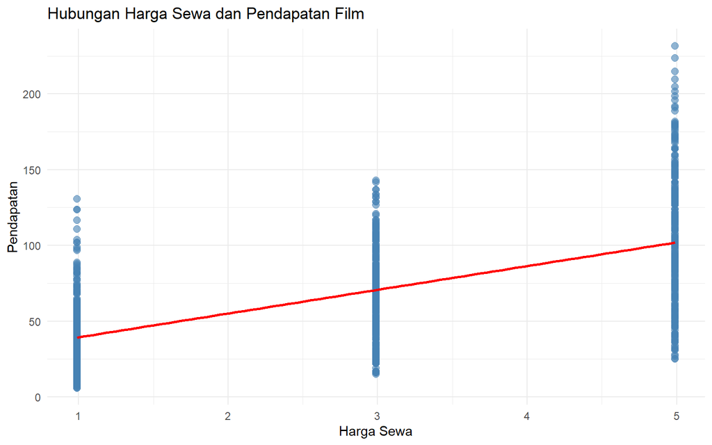

```r
ggplot(datafilm, aes(x = rental_rate, y = revenue)) +
  geom_point(color = "steelblue", size = 2.5, alpha = 0.6) +
  geom_smooth(method = "lm", se = FALSE, color = "red") +
  labs(
    title = "Hubungan Harga Sewa dan Pendapatan Film",
    x = "Harga Sewa",
    y = "Pendapatan"
  ) +
  theme_minimal()
```

Interpretasi: Harga sewa di Sakila hanya terdiri dari tiga nilai diskrit ($0.99, $2.99, $4.99), sehingga titik-titik membentuk tiga kolom vertikal. Garis regresi menunjukkan tren positif, namun perlu diperhatikan bahwa ada beberapa titik yang menyimpang dari tren umum, yang mungkin menunjukkan adanya faktor lain yang mempengaruhi pendapatan selain harga sewa.

### 5.2 Histogram Distribusi Durasi Film

Visualisasi ini digunakan untuk melihat distribusi durasi film pada database Sakila.

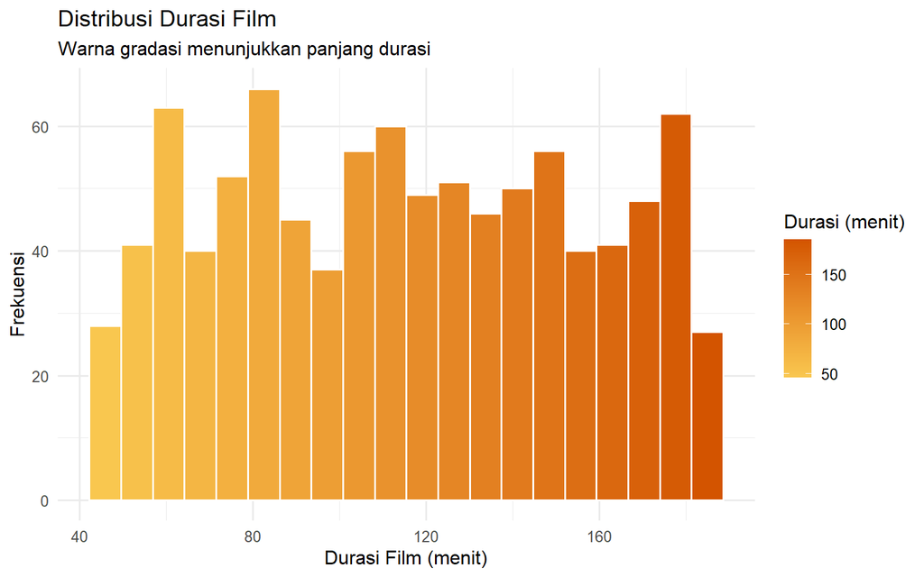

```r
ggplot(datafilm, aes(x = length)) +
  geom_histogram(
    aes(fill = after_stat(x)),   # gradasi warna berdasarkan nilai x
    bins  = 20,
    color = "white"
  ) +
  scale_fill_gradient(
    low  = "#f9c74f",   # kuning untuk durasi pendek
    high = "#d35400",   # oranye tua untuk durasi panjang
    name = "Durasi (menit)"
  ) +
  labs(
    title    = "Distribusi Durasi Film",
    subtitle = "Warna gradasi menunjukkan panjang durasi",
    x        = "Durasi Film (menit)",
    y        = "Frekuensi"
  ) +
  theme_minimal(base_size = 12)
```

### 5.3 Bar Chart Top 10 Film dengan Pendapatan Tertinggi

Visualisasi ini digunakan untuk menampilkan 10 film dengan pendapatan tertinggi, sehingga dapat dilihat film mana yang paling sukses secara finansial.

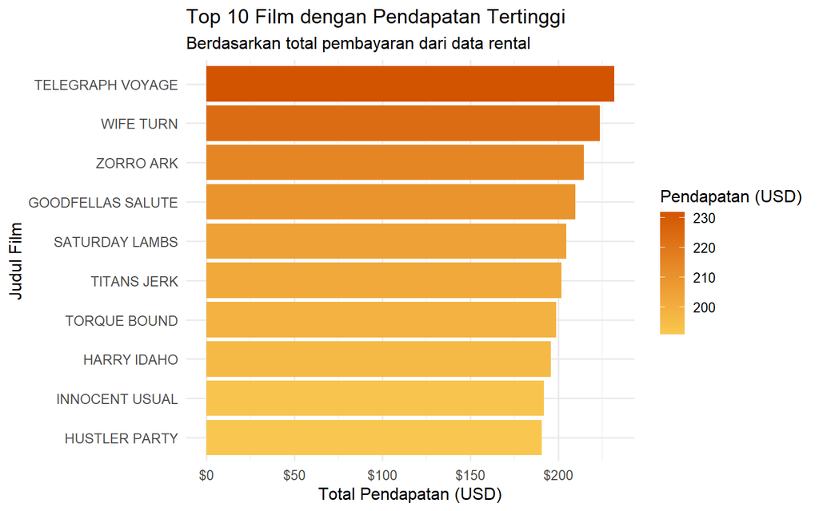

```r
topfilm <- datafilm %>%
  arrange(desc(revenue)) %>%
  head(10)

ggplot(topfilm,
       aes(x     = reorder(title, revenue),
           y     = revenue,
           fill  = revenue)) +
  geom_bar(stat = "identity") +
  scale_fill_gradient(
    low  = "#f9c74f",
    high = "#d35400",
    name = "Pendapatan (USD)"
  ) +
  scale_y_continuous(labels = dollar_format(prefix = "$")) +
  coord_flip() +
  labs(
    title    = "Top 10 Film dengan Pendapatan Tertinggi",
    subtitle = "Berdasarkan total pembayaran dari data rental",
    x        = "Judul Film",
    y        = "Total Pendapatan (USD)"
  ) +
  theme_minimal(base_size = 12)
```

## 6 ANALISIS STATISTIK

### 6.1 Analisis Korelasi (Scatter Plot)

$$r = \frac{\sum_{i=1}^{n}(x_i -
\bar{x})(y_i - \bar{y})}
{\sqrt{\sum_{i=1}^{n}(x_i-\bar{x})^2 \cdot
\sum_{i=1}^{n}(y_i-\bar{y})^2}}$$

```r
cor_value <- cor(datafilm$rental_rate, datafilm$revenue)
cor_value
```

```
## [1] 0.608325
```

Interpretasi: Nilai korelasi Pearson sebesar $r = 0.608$ menunjukkan adanya hubungan positif dengan kekuatan sedang antara harga sewa dan pendapatan film. Artinya, film dengan harga sewa yang lebih tinggi cenderung menghasilkan pendapatan yang lebih besar.

### 6.2 Analisis Statistik

```r
summary(datafilm$length)
```

```
##    Min. 1st Qu.  Median    Mean 3rd Qu.    Max.
##   46.00   80.25  114.00  115.49  150.00  185.00
```

```r
shapiro.test(datafilm$length)
```

```
##
##  Shapiro-Wilk normality test
##
## data:  datafilm$length
## W = 0.95573, p-value < 2.2e-16
```

Interpretasi: Hasil uji Shapiro-Wilk menghasilkan nilai $W = 0.9557$ dengan $p$-value < $2.2 \times 10^{-16}$. Karena $p$-value $< 0.05$, maka **$H_0$ ditolak**. Hal ini secara statistik membuktikan bahwa data durasi film **tidak berdistribusi normal**. Meskipun data tidak berdistribusi normal secara statistik, ukuran sampel yang cukup besar membuat analisis regresi linear masih dapat digunakan sebagai pendekatan eksploratif.

### 6.3 Analisis Deskriptif Top 10 Film (Bar Chart)

```r
topfilm %>%
  summarise(avg_rate = mean(rental_rate),
            avg_length = mean(length),
            avg_revenue = mean(revenue))
```

```
##   avg_rate avg_length avg_revenue
## 1     4.99      123.9     206.317
```

## 7 REGRESI LINEAR

```r
model <- lm(revenue ~ rental_rate + length, data = datafilm)
summary(model)
```

```
##
## Call:
## lm(formula = revenue ~ rental_rate + length, data = datafilm)
##
## Residuals:
##     Min      1Q  Median      3Q     Max
## -78.176 -22.525  -3.345  19.900 130.699
##
## Coefficients:
##             Estimate Std. Error t value Pr(>|t|)
## (Intercept) 26.82875    3.77057   7.115 2.19e-12 ***
## rental_rate 15.68089    0.66108  23.720  < 2e-16 ***
## length      -0.02733    0.02684  -1.018    0.309
## ---
## Signif. codes:  0 '***' 0.001 '**' 0.01 '*' 0.05 '.' 0.1 ' ' 1
##
## Residual standard error: 33.58 on 955 degrees of freedom
## Multiple R-squared:  0.3707, Adjusted R-squared:  0.3694
## F-statistic: 281.3 on 2 and 955 DF,  p-value: < 2.2e-16
```

Interpretasi: Hasil regresi menunjukkan bahwa rental_rate berpengaruh positif dan signifikan terhadap revenue, artinya semakin tinggi harga sewa maka revenue meningkat. Sementara itu, length tidak berpengaruh signifikan terhadap revenue karena p-value > 0.05. Nilai R-squared sebesar 0.3707 menunjukkan bahwa model menjelaskan sekitar 37.07% variasi revenue.

## 8 PERSAMAAN REGRESI MATEMATIS

### 8.1 Persamaan umum:

$$Y = \beta_0 + \beta_1 X_1 + \beta_2 X_2
+ \varepsilon$$

Di mana:

- $Y$ = Total pendapatan film (USD)
- $X_1$ = Harga sewa film (`rental_rate`)
- $X_2$ = Durasi film (`length`)
- $\varepsilon$ = Error/residual

### 8.2 Persamaan regresi hasil estimasi:

```r
b0 <- round(coef(model)[1], 3)
b1 <- round(coef(model)[2], 3)
b2 <- round(coef(model)[3], 3)
```

$$\hat{Y} = 26.829 + (15.681)X_1 + (-0.027)X_2$$

**Interpretasi:**

- **Intercept ($\beta_0$):** Ketika harga sewa dan durasi film diasumsikan bernilai nol secara teoritis, estimasi pendapatan adalah sebesar $26.829.
- **Koefisien $\beta_1$ (rental_rate):** Setiap kenaikan harga sewa sebesar $1, pendapatan diperkirakan meningkat sebesar $15.681, dengan asumsi durasi film konstan. Koefisien ini signifikan secara statistik.
- **Koefisien $\beta_2$ (length):** Durasi film memiliki pengaruh yang sangat kecil dan negatif terhadap pendapatan ($-0.027 per menit). Hal ini menunjukkan durasi bukan prediktor utama pendapatan dalam model ini.
- **$R^2$:** Model mampu menjelaskan sebagian variasi pendapatan, namun nilai $R^2$ yang tidak terlalu tinggi mengindikasikan masih banyak faktor lain di luar model yang memengaruhi pendapatan film.

## 9 STATISTIK RINGKAS

```r
summary_stats <- datafilm %>%
  summarise(
    avg_length = mean(length, na.rm=TRUE),
    avg_rate = mean(rental_rate, na.rm=TRUE),
    total_revenue = sum(revenue, na.rm=TRUE)
  )
summary_stats
```

```
##   avg_length avg_rate total_revenue
## 1   115.4906 2.977474      67406.56
```

## 10 PEMUTUSAN KONEKSI

```r
dbDisconnect(con)
```

Analisis oleh **Astrella Fausta F.** | NIM: M0725003 | Kelas SIM-D  
Mata Kuliah: Sistem Informasi Manajemen | Universitas Sebelas Maret | 2026